# Avaliação 3 - Valor: 34 pontos

Introdução à Ciência de Dados - 2025  
Bacharelado em Administração

Autores

Arthur Henrique

Alexia Luisa

caroline lopes

Gabriel Barbosa

Data de Publicação

9 de julho de 2025

## Questão 1

### Inferência sobre Proporções Populacionais

**a)**

```r
# Dados da pesquisa
respondentes_A <- 350
satisfeitos_A <- 273
respondentes_B <- 290
satisfeitos_B <- 198
```

```r
# Estimativa pontual da proporção de clientes satisfeitos do grupo A
prop_A_ponto <- satisfeitos_A / respondentes_A
cat("Proporção Categoria A:", round(prop_A_ponto, 3))
```

```
Proporção Categoria A: 0.78
```

```r
# Estimativa pontual da proporção de clientes satisfeitos do grupo B
prop_B_ponto <- satisfeitos_B / respondentes_B
cat("Proporção Categoria B:", round(prop_B_ponto, 3))
```

```
Proporção Categoria B: 0.683
```

```r
# Estimativa pontual da diferença entre as proporções
dif_ponto <- prop_A_ponto - prop_B_ponto
cat("Diferença (A - B):", round(dif_ponto, 3))
```

```
Diferença (A - B): 0.097
```

**b)** Estimativas pontuais são palpites vindos de testes e não mostram dúvida na coleta de dados. Já as Intervalos de confiança são um conjunto de valores possíveis para toda a população e deixam as conclusões estatísticas mais confiáveis.

**c)**

```r
# Intervalo de confiança para a diferença entre proporções

teste_prop_dif <- prop.test(x = c(satisfeitos_A, satisfeitos_B), n = c(respondentes_A, respondentes_B), conf.level = 0.95)

# Exibindo o resultado do intervalo de confiança
print(teste_prop_dif)
```

```
    2-sample test for equality of proportions with continuity correction

data:  c(satisfeitos_A, satisfeitos_B) out of c(respondentes_A, respondentes_B)
X-squared = 7, df = 1, p-value = 0.007
alternative hypothesis: two.sided
95 percent confidence interval:
 0.0251 0.1693
sample estimates:
prop 1 prop 2
 0.780  0.683
```

**d)**

A saída (conf.int) mostra o intervalo de confiança de 95% para a diferença observada entre as proporções (proporção de A menos a proporção de B). Se esse intervalo não incluir o valor zero, isso mostra uma diferença estatisticamente relevante entre as proporções dos dois grupos, considerando um nível de significância de 5%. Um intervalo totalmente positivo indica que a Categoria A possui uma parcela consideravelmente superior de clientes satisfeitos. Se for inteiramente negativo, o contrário disso é sugerido. A inclusão do zero nesse intervalo implica que não há indícios estatísticos fortes de uma diferença notável na proporção de clientes satisfeitos entre as duas categorias.

**e.1)**

$$\begin{cases}
H_0: p_A ≤ 0.70 \\
H_A: p_A > 0.70
\end{cases}$$

**e.2)**

```r
# Teste de hipótese unilateral para proporção da Categoria A

prop_referencia <- 0.70
teste_prop_A <- prop.test(x = satisfeitos_A, n = respondentes_A, p = prop_referencia, alternative = "greater", conf.level = 0.95)

# Exibindo o resultado do teste de hipótese
print(teste_prop_A)
```

```
    1-sample proportions test with continuity correction

data:  satisfeitos_A out of respondentes_A, null probability prop_referencia
X-squared = 10, df = 1, p-value = 0.0007
alternative hypothesis: true p is greater than 0.7
95 percent confidence interval:
 0.74 1.00
sample estimates:
   p
0.78
```

**e.3)**

Com um valor-p de 0.0007, que é muito menor que 0.05, rejeitamos a hipótese de que a proporção de satisfeitos na Categoria A é de 70% ou menos. Há evidências estatísticas fortes de que a proporção de clientes satisfeitos na Categoria A é significativamente maior que 70%.

## Questão 2

### Inferência sobre Médias Populacionais

```r
# Cria a data.frame dados_entrega
dados_entrega <- data.frame(
  tempo = c(
    1.9908307, 3.7595980, 3.9207872, 1.9499968, 2.5570788, 2.9083451,
    3.8215787, 3.4254931, 4.1066170, 3.7159112, 2.3757705, 4.3799877,
    4.0898537, 4.6885358, 1.9032753, 4.9526208, 4.7632426, 3.5487350,
    5.2520306, 4.5840950, 2.7728566, 1.6544221, 1.9158527, 3.3874123,
    3.1677474, 4.2208561, 2.7834305, 2.9044544, 4.5360855, 2.2195599,
    2.7240852, 2.6655864, 1.4009759, 3.4665378, 3.3535627, 4.6972176,
    1.9733366, 2.5457229, 2.2336230, 2.6573906, 2.6681639, 3.1323411,
    2.4254247, 2.7917952, 4.9867621, 2.8329370, 2.8299644, 3.5470596,
    1.4070574, 3.1499424, 1.9685541, 2.4178228, 3.4466604, 3.6865291,
    3.3801921, 3.5045991, 2.2455080, 4.4135944, 3.2958687, 3.3348655,
    0.2198195, 1.6197339, 2.4793752, 3.6855232, 2.6521006, 4.5120387,
    4.4196294, 1.1254838, 2.1009464, 1.8516211, 2.5130132, 2.6551619,
    0.8074057, 4.2885169, 2.6779839
  ),
  parceiro = c(
    rep("Atual", 35),
    rep("Novo", 40)
  )
)
```

**a)**

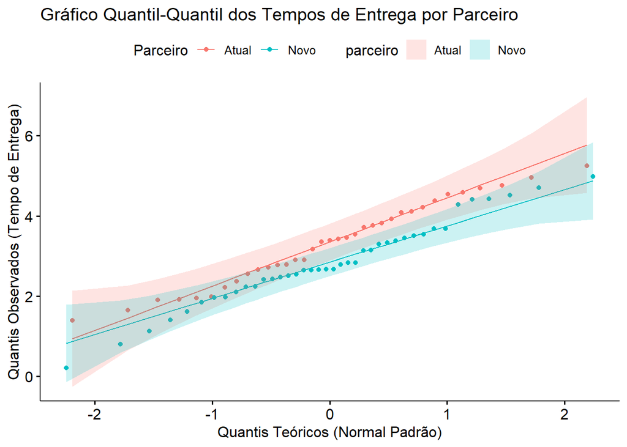

```r
# Gráfico quantile-quantile para verificar normalidade dos dados
grafico_qq <- ggqqplot(dados_entrega, x = "tempo", color = "parceiro") +
  labs(title = "Gráfico Quantil-Quantil dos Tempos de Entrega por Parceiro",
       color = "Parceiro",
       x = "Quantis Teóricos (Normal Padrão)",
       y = "Quantis Observados (Tempo de Entrega)")

print(grafico_qq)
```

**b)**

```r
# Estimativa por intervalo de confiança para a diferença entre médias

teste_t <- t.test(tempo ~ parceiro, data = dados_entrega, conf.level = 0.95)

print(teste_t)
```

```
    Welch Two Sample t-test

data:  tempo by parceiro
t = 2, df = 72, p-value = 0.05
alternative hypothesis: true difference in means between group Atual and group Novo is not equal to 0
95 percent confidence interval:
 -0.000512  0.962466
sample estimates:
mean in group Atual  mean in group Novo
               3.31                2.83
```

**c)**

```r
# Dados
media_atual <- 3.31
media_novo <- 2.83
```

```r
# Atual
cat("Tempo médio para Parceiro Atual:", media_atual)
```

```
Tempo médio para Parceiro Atual: 3.31
```

```r
# Novo
cat("Tempo médio para Parceiro Novo:", media_novo)
```

```
Tempo médio para Parceiro Novo: 2.83
```

```r
# Estimativa pontual da diferença entre os tempos médios
diferenca_medias <- media_atual - media_novo

cat("Diferença entre os tempos médios de entrega (Atual - Novo):", diferenca_medias)
```

```
Diferença entre os tempos médios de entrega (Atual - Novo): 0.48
```

**d)**

A intervalo de confiança de 95% aponta que a variação entre as médias de tempo de entrega (Atual menos Novo) fica entre -0,000512 e 0,962466 dias. Dado que esse intervalo inclui zero, não podemos afirmar, com certeza estatística de 5%, que um dos parceiros leva, em média, mais tempo para entregar do que o outro. Ao incluir o zero nessa faixa, quer dizer que é possível que a diferença real entre os tempos médios de entrega seja nula, ou seja, que não existe diferença significativa entre eles.